# Binomial model - exercise

In this exercise, we fit a binomial regression model to the snow vole data.  
In our data set, called ‘dati.mod.csv’, the column ‘CattSiNo’ has a 0 for traps were no captures were recorded, and a 1 for traps were at least one capture occurred. This is our dependent variable.  
For the purpose of our exercise, we use the columns from 8 to 15 as explanatory variables.

```r
dati.mod <- read.csv("data/dati.mod.csv")
head(dati.mod)
```

|  | X | IDtrappola | CattSiNo | Ncatture | Animalidiversi | Noccasioni | Esp | Incl | Alt | copveg | NSpecie | media.rocce | mediana.rocce | sd.rocce | Esp.tr |
| --- | --- | --- | --- | --- | --- | --- | --- | --- | --- | --- | --- | --- | --- | --- | --- |
| 1 | 1 | 1 | 0 | 0 | 0 | 15 | 234 | 13 | 2711 | 45 | 23 | 85.66667 | 96 | 23.28805 | -126 |
| 2 | 2 | 2 | 1 | 1 | 1 | 15 | 294 | 16 | 2713 | 35 | 16 | 98.00000 | 76 | 69.65630 | -66 |
| 3 | 3 | 3 | 0 | 0 | 0 | 15 | 310 | 0 | 2711 | 25 | 13 | 67.00000 | 62 | 19.00000 | -50 |
| 4 | 4 | 4 | 0 | 0 | 0 | 15 | 293 | 8 | 2715 | 50 | 23 | 55.00000 | 36 | 38.22303 | -67 |
| 5 | 5 | 5 | 0 | 0 | 0 | 15 | 294 | 11 | 2719 | 25 | 21 | 84.00000 | 47 | 69.34695 | -66 |
| 6 | 6 | 6 | 0 | 0 | 0 | 15 | 310 | 7 | 2722 | 55 | 20 | 65.66667 | 36 | 55.77036 | -50 |

```r
varexpl <- dati.mod[,8:15]
head(varexpl)
```

|  | Incl | Alt | copveg | NSpecie | media.rocce | mediana.rocce | sd.rocce | Esp.tr |
| --- | --- | --- | --- | --- | --- | --- | --- | --- |
| 1 | 13 | 2711 | 45 | 23 | 85.66667 | 96 | 23.28805 | -126 |
| 2 | 16 | 2713 | 35 | 16 | 98.00000 | 76 | 69.65630 | -66 |
| 3 | 0 | 2711 | 25 | 13 | 67.00000 | 62 | 19.00000 | -50 |
| 4 | 8 | 2715 | 50 | 23 | 55.00000 | 36 | 38.22303 | -67 |
| 5 | 11 | 2719 | 25 | 21 | 84.00000 | 47 | 69.34695 | -66 |
| 6 | 7 | 2722 | 55 | 20 | 65.66667 | 36 | 55.77036 | -50 |

```r
NA
```

## Data exploration

First look at the dependent variable:

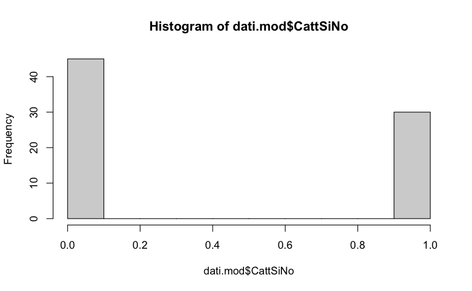

```r
hist(dati.mod$CattSiNo)
```

```r
table(dati.mod$CattSiNo)
```

```
 0  1
45 30
```

Now look at the explanatory variables:

```r
summary(varexpl)
```

```
      Incl            Alt           copveg         NSpecie       media.rocce
 Min.   : 0.00   Min.   :2711   Min.   : 0.00   Min.   : 0.00   Min.   : 33.33
 1st Qu.: 8.00   1st Qu.:2718   1st Qu.: 7.50   1st Qu.:10.00   1st Qu.: 68.17
 Median :12.00   Median :2725   Median :25.00   Median :14.00   Median : 81.67
 Mean   :13.27   Mean   :2725   Mean   :25.72   Mean   :15.15   Mean   : 88.84
 3rd Qu.:20.00   3rd Qu.:2728   3rd Qu.:42.50   3rd Qu.:21.00   3rd Qu.:102.17
 Max.   :38.00   Max.   :2744   Max.   :80.00   Max.   :32.00   Max.   :190.67
 mediana.rocce       sd.rocce           Esp.tr
 Min.   : 28.00   Min.   :  5.508   Min.   :-126.00
 1st Qu.: 53.00   1st Qu.: 23.359   1st Qu.: -42.50
 Median : 67.00   Median : 41.065   Median : -17.00
 Mean   : 73.27   Mean   : 54.620   Mean   : -19.49
 3rd Qu.: 88.00   3rd Qu.: 73.980   3rd Qu.:  11.50
 Max.   :212.00   Max.   :225.247   Max.   :  62.00
```

Explore the pairwise relationship between the Y and X variables:

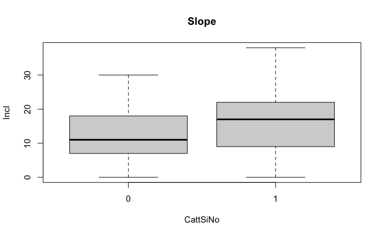

```r
with(dati.mod,
     boxplot(Incl ~ CattSiNo, main="Slope"))
```

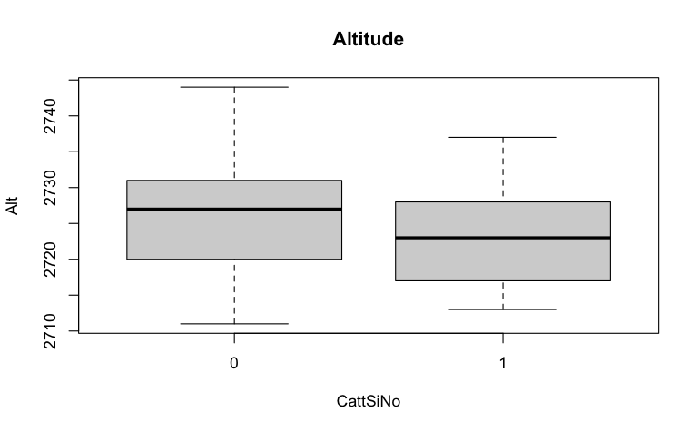

```r
with(dati.mod,
     boxplot(Alt ~ CattSiNo, main="Altitude"))
```

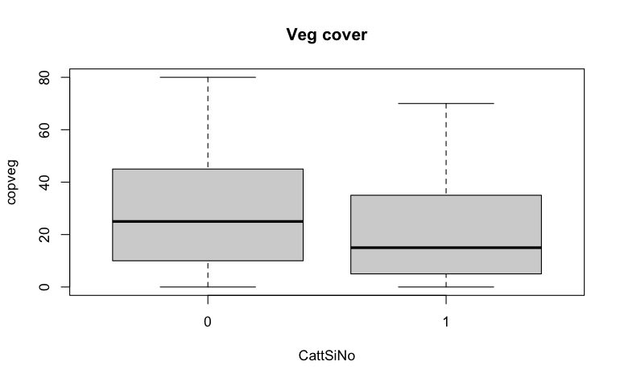

```r
with(dati.mod,
     boxplot(copveg ~ CattSiNo, main="Veg cover"))
```

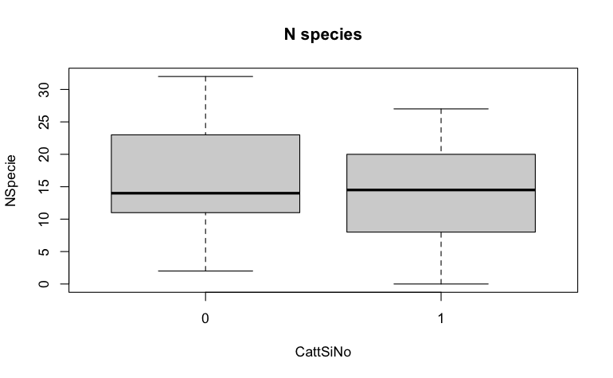

```r
with(dati.mod,
     boxplot(NSpecie ~ CattSiNo, main="N species"))
```

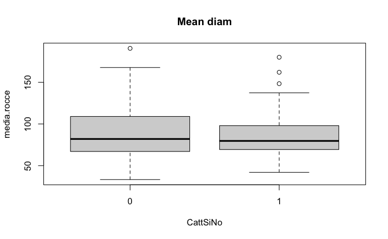

```r
with(dati.mod,
     boxplot(media.rocce ~ CattSiNo, main="Mean diam"))
```

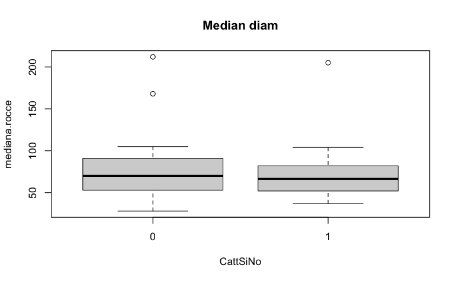

```r
with(dati.mod,
     boxplot(mediana.rocce ~ CattSiNo, main="Median diam"))
```

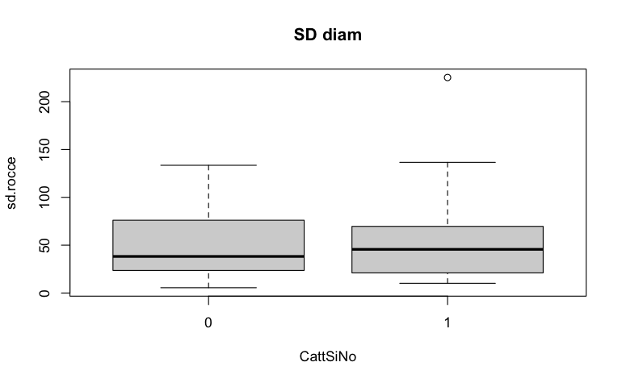

```r
with(dati.mod,
     boxplot(sd.rocce ~ CattSiNo, main="SD diam"))
```

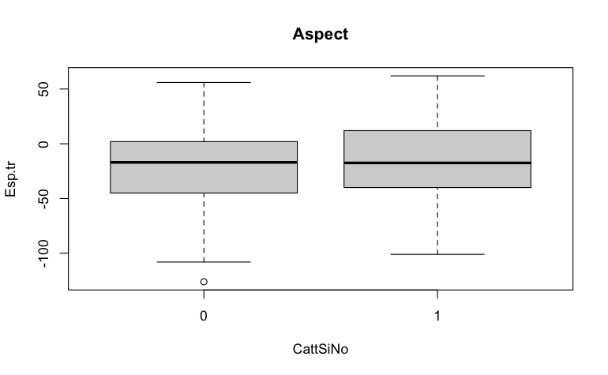

```r
with(dati.mod,
     boxplot(Esp.tr ~ CattSiNo, main="Aspect"))
```

### Cleveland dotplot

```r
par(mfrow=c(1,2))
dotchart(dati.mod$sd.rocce,
         ylab = "Order of observations",
         xlab = "SD diam", main = "")
dotchart(dati.mod$sd.rocce,
         groups = dati.mod$CattSiNo,
         ylab = "CattSiNo",
         xlab = "SD diam", main = "")
```

[figure not shown]

```r
par(mfrow=c(1,1))
```

```r
# eliminazione dell'outlier
subset(dati.mod, dati.mod$sd.rocce > 200)
```

|  | X | IDtrappola | CattSiNo | Ncatture | Animalidiversi | Noccasioni | Esp | Incl | Alt | copveg | NSpecie | media.rocce | mediana.rocce | sd.rocce | Esp.tr |
| --- | --- | --- | --- | --- | --- | --- | --- | --- | --- | --- | --- | --- | --- | --- | --- |
| 31 | 31 | 31 | 1 | 2 | 2 | 15 | 62 | 20 | 2713 | 15 | 15 | 180 | 56 | 225.2465 | 62 |

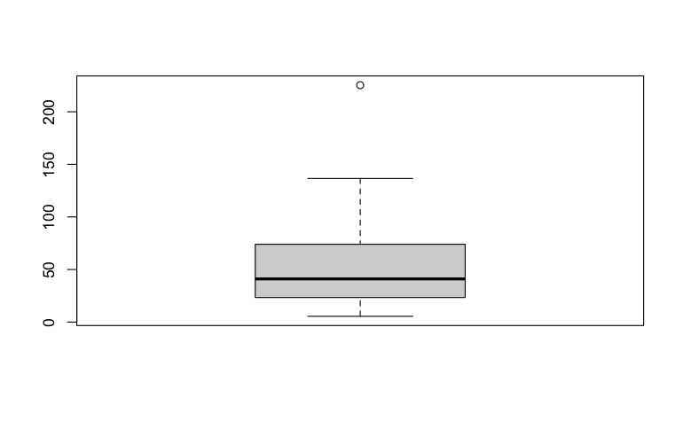

```r
dati.mod.new <- subset(dati.mod, dati.mod$sd.rocce < 200)

# trasformazione della variabile x
boxplot(dati.mod$sd.rocce)
```

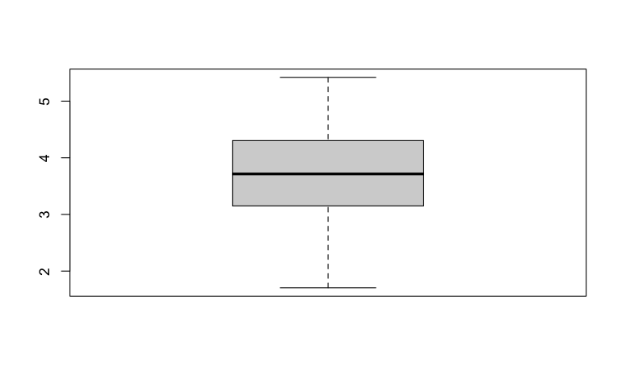

```r
boxplot(log(dati.mod$sd.rocce))
```

```r
dati.mod.new2 <- cbind(dati.mod, logSD = log(dati.mod$sd.rocce))
dati.mod.new2 <- data.frame(dati.mod, logSD = log(dati.mod$sd.rocce))
head(dati.mod.new2)
```

|  | X | IDtrappola | CattSiNo | Ncatture | Animalidiversi | Noccasioni | Esp | Incl | Alt | copveg | NSpecie | media.rocce | mediana.rocce | sd.rocce | Esp.tr | logSD |
| --- | --- | --- | --- | --- | --- | --- | --- | --- | --- | --- | --- | --- | --- | --- | --- | --- |
| 1 | 1 | 1 | 0 | 0 | 0 | 15 | 234 | 13 | 2711 | 45 | 23 | 85.66667 | 96 | 23.28805 | -126 | 3.147940 |
| 2 | 2 | 2 | 1 | 1 | 1 | 15 | 294 | 16 | 2713 | 35 | 16 | 98.00000 | 76 | 69.65630 | -66 | 4.243573 |
| 3 | 3 | 3 | 0 | 0 | 0 | 15 | 310 | 0 | 2711 | 25 | 13 | 67.00000 | 62 | 19.00000 | -50 | 2.944439 |
| 4 | 4 | 4 | 0 | 0 | 0 | 15 | 293 | 8 | 2715 | 50 | 23 | 55.00000 | 36 | 38.22303 | -67 | 3.643438 |
| 5 | 5 | 5 | 0 | 0 | 0 | 15 | 294 | 11 | 2719 | 25 | 21 | 84.00000 | 47 | 69.34695 | -66 | 4.239122 |
| 6 | 6 | 6 | 0 | 0 | 0 | 15 | 310 | 7 | 2722 | 55 | 20 | 65.66667 | 36 | 55.77036 | -50 | 4.021243 |

```r
NA
```